# simulate_data2

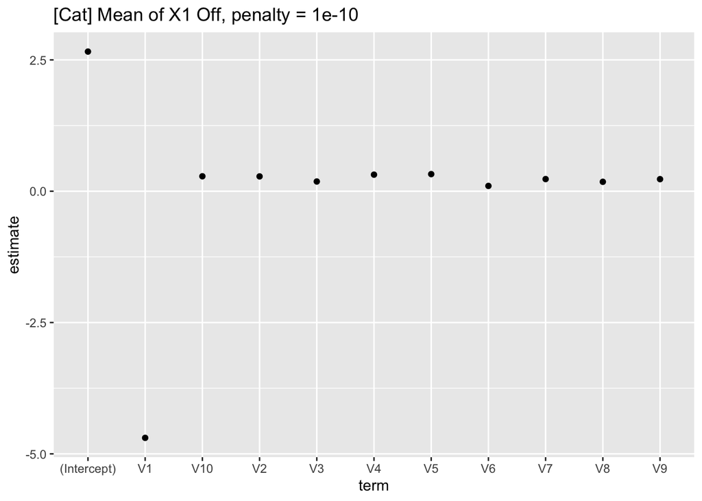

```r
test_lasso(synth_cat3, conf_cat3, lasso_mod, "[Cat] Mean of X1 Off")
```

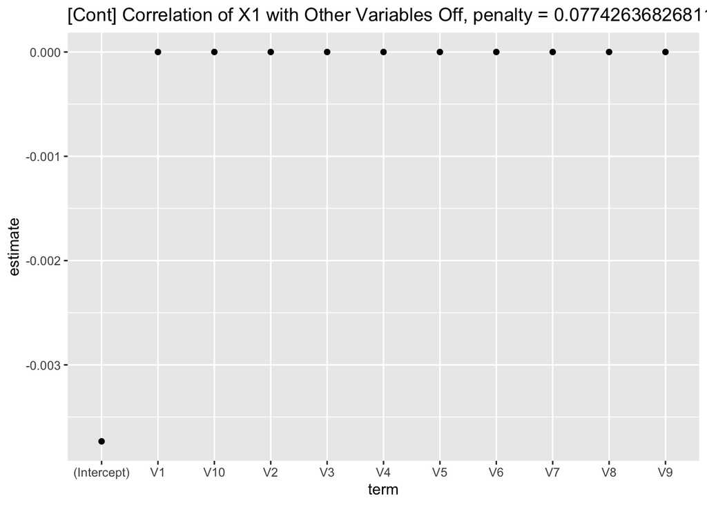

```r
test_lasso(synth_cont4, conf_cont4, lasso_mod, "[Cont] Correlation of X1 with Other Variables Off")
```

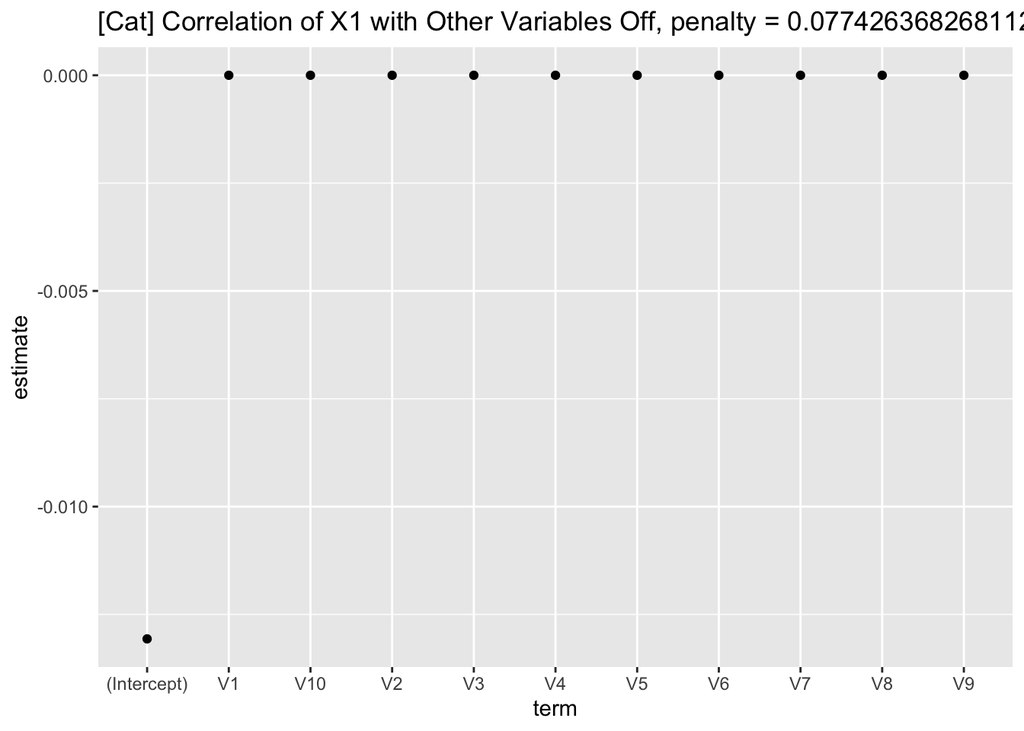

```r
test_lasso(synth_cat4, conf_cat4, lasso_mod, "[Cat] Correlation of X1 with Other Variables Off")
```

So in general the lasso regression picks out the “right” term when the mean is off, but either sets everything to 0 or doesn’t use the “right” term when the correlations are off.

Plotting how the metrics change for different values of Cp with and without cross-validation (with and without doing hyperparameter tuning, which automatically does CV, with only one option in our grid)

```r
# going to just test this for the meanwrong dataset
#synth_cont3, conf_cont3
Cps = seq(0.0001, .1, length.out = 10)

rpart_rec <- recipe(.source_label ~ ., data = discrimination(synth_cont3, conf_cont3)$combined_data)

cp_cross_val = data.frame(matrix(ncol = 5))
names(cp_cross_val) = c("specks", "pmse", "auc", "cv", "cp")
for (cp in Cps){
  grid = tibble(cost_complexity = c(cp)) # single option for hyperparameter tuning, to test cv
  # make discriminator
  d <- discrimination(synth_cont3, conf_cont3) %>%
    add_propensities_tuned(
        grid = grid,
        recipe = rpart_rec,
        spec = tree_mod) %>%
      add_discriminator_auc() %>%
      add_specks() %>%
      add_pmse()

  # extract the metrics and variable importance
  cp_cross_val = rbind(cp_cross_val, c(d$specks, d$pmse, d$discriminator_auc, 1, cp))

  tree_mod_no_tune = decision_tree(cost_complexity = cp) %>%
    set_mode(mode = "classification") %>%
    set_engine(engine = "rpart")

  d <- discrimination(synth_cont3, conf_cont3) %>%
    add_propensities(
        recipe = rpart_rec,
        spec = tree_mod_no_tune) %>%
      add_discriminator_auc() %>%
      add_specks() %>%
      add_pmse()
  cp_cross_val = rbind(cp_cross_val, c(d$specks, d$pmse, d$discriminator_auc, 0, cp))
}
```

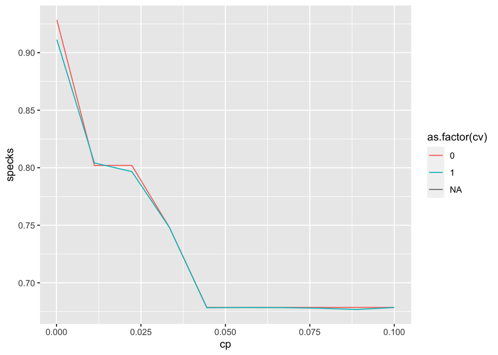

```r
ggplot(cp_cross_val, aes(x = cp, y = specks, group = as.factor(cv), color = as.factor(cv))) +
  geom_line()
```

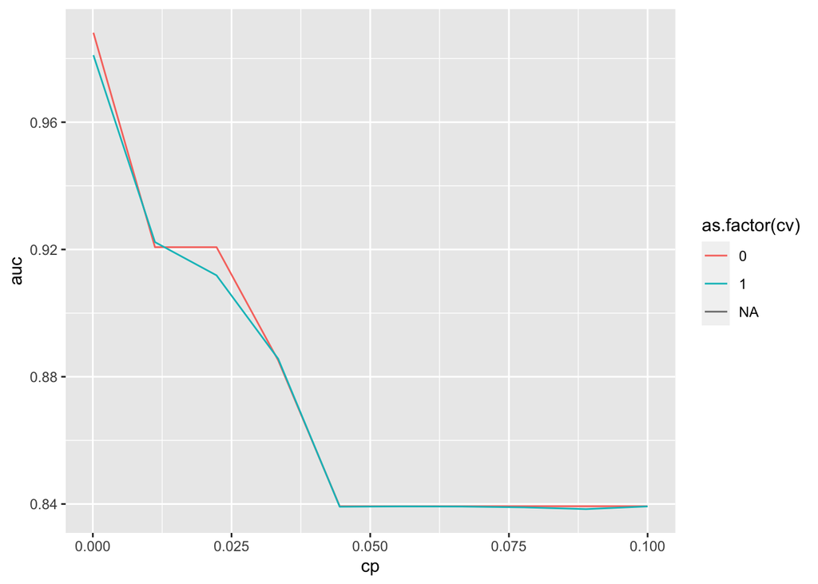

```r
ggplot(cp_cross_val, aes(x = cp, y = auc, group = as.factor(cv), color = as.factor(cv))) +
  geom_line()
```

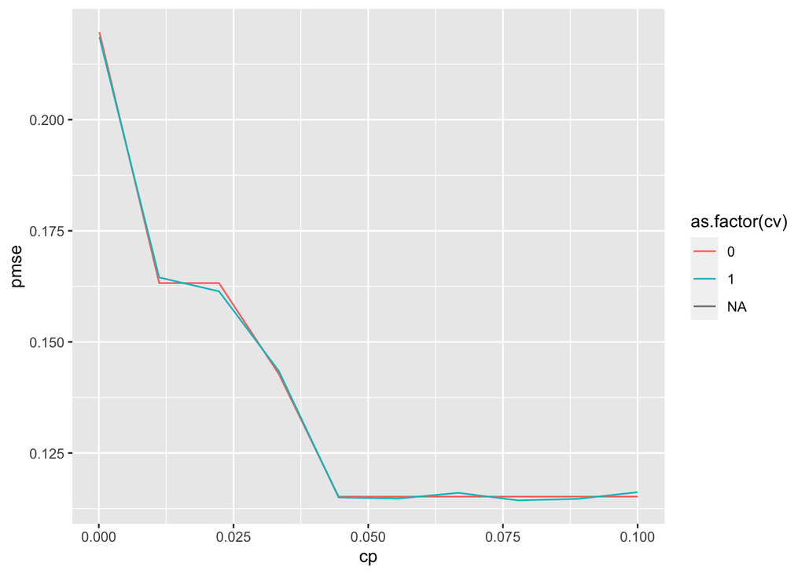

```r
ggplot(cp_cross_val, aes(x = cp, y = pmse, group = as.factor(cv), color = as.factor(cv))) +
  geom_line()
```

When we use cross-validation (through using add_propensities_tuned but forcing it to only have one option), we observe that in general the metrics are similar to not using cross validation for various values of cp. As cp gets larger, so trees get shallower, we see a stair-step cutoff and we potentially see overfitting (red above blue) for very small cp without cross-validation, as well as blue above red (so cross-validation improves our fits for some large-ish values of cp) at some points. Would like to discuss!